# TRABAJO FIN DE MÁSTER

## **ANÁLISIS DE FACTORES QUE INTERVIENEN EN LOS SALARIOS DE LOS CIENTÍFICOS DE DATOS**

**Angélica Erandi Chaves Mercado**

**NIE: Y8490058J**

## ÍNDICE DE CONTENIDOS

- 1. Introducción
  - 1.1. Contexto y relevancia
  - 1.2. Objetivos del Estudio
- 2. Revisión de la literatura
  - 2.1. Evolución de la profesión de científico de datos
  - 2.2. Factores determinantes en los salarios
- 3. Descripción del dataset
  - 3.1. Origen y características del dataset
  - 3.2. Variables clave
  - 3.3 Exploración inicial
- 4. Análisis exploratorio de datos
  - 4.1 Distribución salarial global
  - 4.2 Impacto de la experiencia
  - 4.3 Comparativa regional
- 5. Modelado predictivo
  - 5.1. Selección de modelos
  - 5.2. Preparación de los datos
  - 5.3. Evaluación del modelo
  - 5.4. Interpretación de resultados
  - 5.5. Entrenamiento de red neuronal y comparación con nuestro modelo entrenado
- 6. Productivización del modelo
- 7. Análisis de resultados, conclusiones y recomendaciones
  - 7.1. Discusión de los hallazgos principales
  - 7.2 Implicaciones para profesionales
  - 7.3 Recomendaciones para la industria
  - 7.4 Limitaciones del análisis
  - 7.5 Trabajo futuro
- Anexo: código

## 1. Introducción

### 1.1. Contexto y relevancia

En la última década, la ciencia de datos se ha consolidado como una de las disciplinas más demandadas en el ámbito laboral. Este auge está impulsado por la explosión de datos generados a nivel global, conocida como "Big Data", que abarca desde datos estructurados, como registros financieros, hasta datos no estructurados, como imágenes y publicaciones en redes sociales. Según informes recientes, se espera que la cantidad de datos generados anualmente alcance los 180 zettabytes para 2025, lo que resalta la necesidad crítica de profesionales capaces de analizar y extraer valor de esta información.

El impacto de la ciencia de datos en el mercado laboral ha sido significativo, redefiniendo roles tradicionales y creando nuevas oportunidades en múltiples sectores, como la salud, las finanzas, la tecnología y el comercio. Profesiones como el Data Scientist o el Data Engineer han sido calificadas repetidamente como algunas de las mejores carreras del mundo debido a su alta demanda, salarios competitivos y posibilidades de crecimiento. Empresas de todos los tamaños, desde startups hasta corporaciones globales, compiten por atraer talento en este campo, reconociendo que el análisis de datos es esencial para la toma de decisiones estratégicas.

Además, la ciencia de datos está promoviendo una democratización del acceso a herramientas analíticas avanzadas, lo que permite a las empresas pequeñas competir con organizaciones más grandes. Sin embargo, esta creciente demanda también ha puesto de manifiesto la necesidad de cerrar brechas de habilidades, especialmente en tecnologías como el aprendizaje automático, la inteligencia artificial y el manejo de grandes volúmenes de datos.

En resumen, el crecimiento de la ciencia de datos no solo está transformando la forma en que las organizaciones operan, sino también cómo planifican su futuro en un mundo cada vez más impulsado por datos. Este impacto, combinado con su versatilidad, convierte a la ciencia de datos en una de las áreas más influyentes y relevantes del siglo XXI.

### 1.2. Objetivos del Estudio

Analizaremos un dataset escogido en kaggle que contiene datos de los salarios de los científicos de datos a lo largo de 2023, así como variables relevantes que pueden influir en los propios salarios.

Este repositorio nos proporciona un amplio conjunto de datos que nos va a permitir hacer un análisis con las siguientes propuestas:

- **1.2.1 Identificar tendencias salariales**
  - Analizar la distribución de los salarios en USD a nivel global.
    - Identificar cómo varían los salarios según:
      - **Nivel de experiencia**: Entry-level (EN), Mid-level (MI), Senior-level (SE).
      - **Tipo de empleo**: Contrato a tiempo completo (FT), contrato temporal (CT), etc.
      - **Trabajo remoto**: Comparar salarios entre empleados que trabajan de manera remota, híbrida o presencial.
- **1.2.2 Estudiar disparidades regionales**
  - Comparar los salarios promedio por región o país.
  - Evaluar cómo la localización de la empresa impacta en los salarios, especialmente en relación con el trabajo remoto.
  - Analizar la diferencia entre países con moneda fuerte (USD, EUR) frente a monedas menos valoradas en el mercado global.
- **1.2.3. Examinar los factores que influyen en los salarios**
  - Evaluar el impacto del tamaño de la empresa en los salarios:
    - Pequeña (S), Mediana (M) o Grande (L).
  - Determinar si ciertas categorías de empleo, como *Machine Learning Engineer* o *Data Scientist*, están mejor remuneradas.
  - Analizar la relación entre el porcentaje de trabajo remoto y los salarios.
  - Explorar si existe alguna correlación entre la ubicación del empleado y su salario.

## 2. Revisión de la literatura

### 2.1. Evolución de la profesión de científico de datos

La profesión de científico de datos ha experimentado un crecimiento exponencial en las últimas dos décadas, convirtiéndose en una de las carreras más demandadas y reconocidas en el mundo laboral. Este auge está estrechamente vinculado al aumento masivo en la generación de datos y a la necesidad de interpretarlos para tomar decisiones estratégicas.

- 2.1.1 Orígenes y evolución:  
  El término "científico de datos" comenzó a ganar popularidad a principios de los años 2000, aunque la práctica de analizar datos se remonta a la estadística tradicional y la minería de datos de finales del siglo XX. En sus primeros días, la ciencia de datos era vista como una extensión de la programación y el análisis estadístico, enfocándose principalmente en la limpieza y manipulación de datos.

Con la explosión del Big Data y el desarrollo de tecnologías como Hadoop y Spark, la ciencia de datos evolucionó hacia un campo multidisciplinario que combina matemáticas, estadística, informática y experiencia en negocios. Paralelamente, la inteligencia artificial y el aprendizaje automático se integraron como elementos esenciales, ampliando el impacto de esta disciplina.

- 2.1.2 Demanda creciente en el mercado laboral:  
  La necesidad de científicos de datos ha crecido de manera exponencial debido a que las empresas reconocen el valor de tomar decisiones basadas en datos. Informes globales señalan que los roles en ciencia de datos, como los de *Data Scientist* y *Machine Learning Engineer*, han estado consistentemente entre los empleos más demandados, con salarios competitivos y oportunidades de crecimiento.

Sectores como la salud, las finanzas, la tecnología y el comercio minorista han liderado la contratación de profesionales en este campo, destacando su versatilidad para resolver problemas complejos y optimizar procesos.

- 2.1.3 Transformaciones recientes:  
  En los últimos años, la automatización y la democratización de herramientas analíticas han modificado el rol del científico de datos. Plataformas como AutoML y soluciones basadas en inteligencia artificial han reducido las barreras técnicas, permitiendo que profesionales no especializados realicen análisis avanzados. Sin embargo, el científico de datos sigue siendo esencial para diseñar, interpretar y aplicar estos modelos de manera ética y efectiva.
- 2.1.4 Proyección futura:  
  De cara al futuro, la profesión de científico de datos seguirá evolucionando en respuesta a tendencias emergentes como:
  - **Hiperautomatización**: La integración de la inteligencia artificial y la automatización en flujos de trabajo, permitiendo un análisis más rápido y preciso.
  - **Ética y privacidad de los datos**: El enfoque en la regulación y la gestión responsable de los datos, con roles especializados en ética de la inteligencia artificial.
  - **Especialización**: Aparición de subcampos más específicos, como científicos de datos para sistemas autónomos, sostenibilidad y ciberseguridad.
  - **Integración interdisciplinaria**: Colaboración creciente con áreas como el diseño, la psicología y la biología para resolver problemas multifacéticos.

#### Conclusión:

La profesión de científico de datos no solo ha transformado el panorama laboral, sino también cómo las organizaciones y la sociedad toman decisiones. A medida que el campo madura, su relevancia continuará creciendo, consolidándose como una pieza clave en el desarrollo tecnológico y la innovación global.

### 2.2. Factores determinantes en los salarios

En 2023, los salarios de los científicos de datos siguen siendo elevados en comparación con muchas otras profesiones tecnológicas debido a la alta demanda y la complejidad de las habilidades necesarias. Algunos de los factores determinantes clave para estos salarios incluyen:

- 1. Nivel de Experiencia
     - Entry-level: Los científicos de datos con poca o ninguna experiencia ganan menos, pero incluso en este nivel, los salarios son competitivos debido a la alta demanda de talento.
     - Intermedios: Aquellos con algunos años de experiencia y un portafolio sólido suelen obtener aumentos significativos.
     - Senior/Leadership: Los salarios para roles senior, como científicos de datos principales o gerentes, son significativamente más altos, especialmente si incluyen la gestión de equipos y proyectos estratégicos.
- 2. Habilidades Técnicas y Certificaciones Los científicos de datos con competencias avanzadas y certificaciones en herramientas y tecnologías específicas suelen obtener salarios más altos:
     - **Lenguajes de programación**: Python, R, SQL y Scala.
     - **Plataformas de big data**: Apache Spark, Hadoop.
     - **Machine learning e inteligencia artificial**: Experiencia con frameworks como TensorFlow o PyTorch.
     - **Certificaciones**: Google Data Engineer, Microsoft Azure Data Scientist, AWS Certified Machine Learning.
- 3. Localización Geográfica El lugar de residencia o la sede de la empresa afecta el salario:
     - **Países**: Científicos de datos en EE. UU., Suiza o Alemania suelen tener ingresos más altos que en países emergentes.
     - **Ciudades**: Grandes centros tecnológicos como San Francisco, Nueva York, Londres y Berlín ofrecen mayores salarios debido a la concentración de empresas tecnológicas.
- 4. Modalidad de Trabajo (Remoto vs. Presencial)
     - **Trabajo remoto**: Permite a los profesionales de regiones con costos de vida más bajos trabajar para empresas en países con mayores salarios.
     - **Trabajo presencial**: Puede ofrecer beneficios adicionales como bonificaciones de relocalización, pero en algunos casos los salarios no se ajustan al costo de vida de la región.
- 5. Tamaño de la Empresa
     - **Startups**: Pueden ofrecer salarios competitivos, pero a menudo con más riesgos y compensaciones en forma de equity.
     - **Corporaciones**: Ofrecen paquetes salariales robustos, estabilidad y beneficios adicionales.
- 6. Ámbito Académico y Formación
     - **Nivel de estudios**: Científicos de datos con maestrías o doctorados suelen recibir mejores ofertas salariales.
     - **Áreas de estudio**: Los títulos en ciencia de datos, matemáticas, estadística, informática e inteligencia artificial son los más valorados.
- 7. Tendencias y Demanda del Mercado
     - **Demanda regional**: La escasez de talento en ciertas áreas geográficas o industrias aumenta los salarios.
     - **Nuevas tecnologías**: Experiencia en tecnologías emergentes como aprendizaje profundo, análisis de datos en tiempo real o ingeniería de datos mejora significativamente las ofertas salariales.

## 3. Descripción del dataset

### 3.1. Origen y características del dataset

El repositorio elegido se encuentra en:  
https://www.kaggle.com/datasets/henryshan/2023-data-scientists-salary

El archivo contiene 3755 filas y 11 columnas.

- 3.1.1. Columnas del dataset:
  - 1. *work_year*: Año de la encuesta o recopilación de datos.
  - 2. *experience_level*: Nivel de experiencia del empleado (e.g., Junior, Senior).
  - 3. *employment_type*: Tipo de contrato laboral (e.g., tiempo completo, contrato temporal).
  - 4. *job_title*: Título del puesto de trabajo.
  - 5. *salary*: Salario bruto en la moneda local.
  - 6. *salary_currency*: Moneda del salario.
  - 7. *salary_in_usd*: Salario bruto convertido a USD.
  - 8. *employee_residence*: País de residencia del empleado.
  - 9. *remote_ratio*: Porcentaje de trabajo remoto (0, 50, 100).
  - 10. *company_location*: País de la empresa.
  - 11. *company_size*: Tamaño de la empresa (S: pequeña, M: mediana, L: grande).
- 3.1.2. Muestra de los datos:

| work_year | experience_level | employment_type | job_title | salary | salary_currency | salary_in_usd | employee_residence | remote_ratio | company_location | company_size |
| --- | --- | --- | --- | --- | --- | --- | --- | --- | --- | --- |
| 2023 | SE | FT | Principal Data Scientist | 80000 | EUR | 85847 | ES | 100 | ES | L |
| 2023 | MI | CT | ML Engineer | 30000 | USD | 30000 | US | 100 | US | S |

### 3.2. Variables clave

- **Salario** (`salary`, `salary_in_usd`) El salario es la variable central del análisis, representando los ingresos brutos de los científicos de datos. Se incluye en dos formatos:
  - **`salary`**: Monto bruto en la moneda local de cada empleado.
  - **`salary_in_usd`**: Conversión del salario bruto a dólares estadounidenses (USD) para facilitar comparaciones globales.
- **Experiencia** (`experience_level`) Indica el nivel de experiencia del empleado, clasificado en cuatro categorías principales:
  - **EN (Entry-level)**: Nivel de entrada o principiante.
  - **MI (Mid-level)**: Nivel intermedio.
  - **SE (Senior-level)**: Nivel senior.
  - **EX (Executive-level)**: Nivel ejecutivo o de liderazgo.
- **Habilidades técnicas** (`job_title`) El campo **`job_title`** describe el rol o especialización del empleado, lo que permite identificar qué tipos de habilidades técnicas (e.g., ciencia de datos, ingeniería de ML) están asociados con diferentes niveles salariales.
- **Localización** (`employee_residence`, `company_location`)
  - **`employee_residence`**: País donde reside el empleado.
  - **`company_location`**: País donde se encuentra la empresa.

Estas variables son clave para entender la relación entre los salarios, el lugar de trabajo, y las condiciones laborales como el trabajo remoto.

- **Trabajo remoto** (`remote_ratio`)  
  Proporciona el porcentaje de trabajo remoto que realiza un empleado:
  - **0**: Sin trabajo remoto.
  - **50**: Trabajo híbrido (parcialmente remoto).
  - **100**: Trabajo completamente remoto.
- **Tamaño de la empresa** (`company_size`)  
  Indica el tamaño de la empresa en tres categorías:
  - **S**: Pequeña.
  - **M**: Mediana.
  - **L**: Grande.

Estas variables permiten explorar cómo el contexto empresarial y la localización influyen en los salarios y las condiciones laborales.

### 3.3 Exploración inicial

#### Dimensiones del dataset

El dataset contiene **3755 filas** y **11 columnas**, proporcionando una significativa muestra de datos sobre salarios en ciencia de datos.

#### Tendencias preliminares

- La variable **salary_in_usd** muestra una amplia dispersión, con salarios que varían significativamente entre regiones y niveles de experiencia.
- Los niveles de experiencia más altos (**SE**, **EX**) tienden a concentrar los salarios más elevados.
- La localización influye en los salarios: empleados en países desarrollados tienden a tener mayores ingresos.

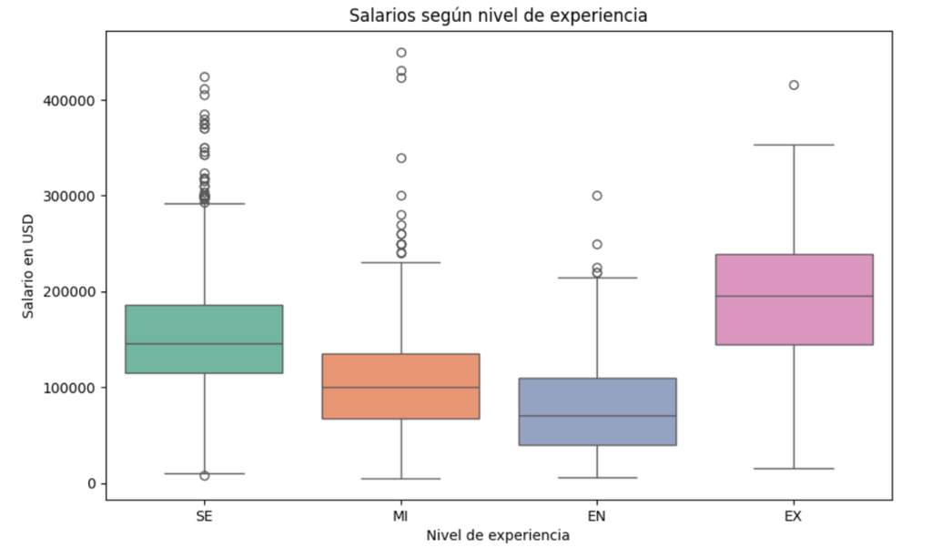

#### Valores atípicos

Se han identificado valores extremos en la variable **salary_in_usd**, correspondientes a salarios muy altos o bajos, lo que sugiere la necesidad de un análisis adicional para determinar su validez.

#### 3.3.4. Datos faltantes

Tras un análisis inicial:

- No se identificaron valores nulos en el dataset.
- Todas las columnas parecen estar completamente pobladas, lo que simplifica el análisis.

#### 3.3.5. Observaciones adicionales

- La variable **remote_ratio** permite identificar tendencias relacionadas con el trabajo remoto, siendo un factor relevante post-pandemia.

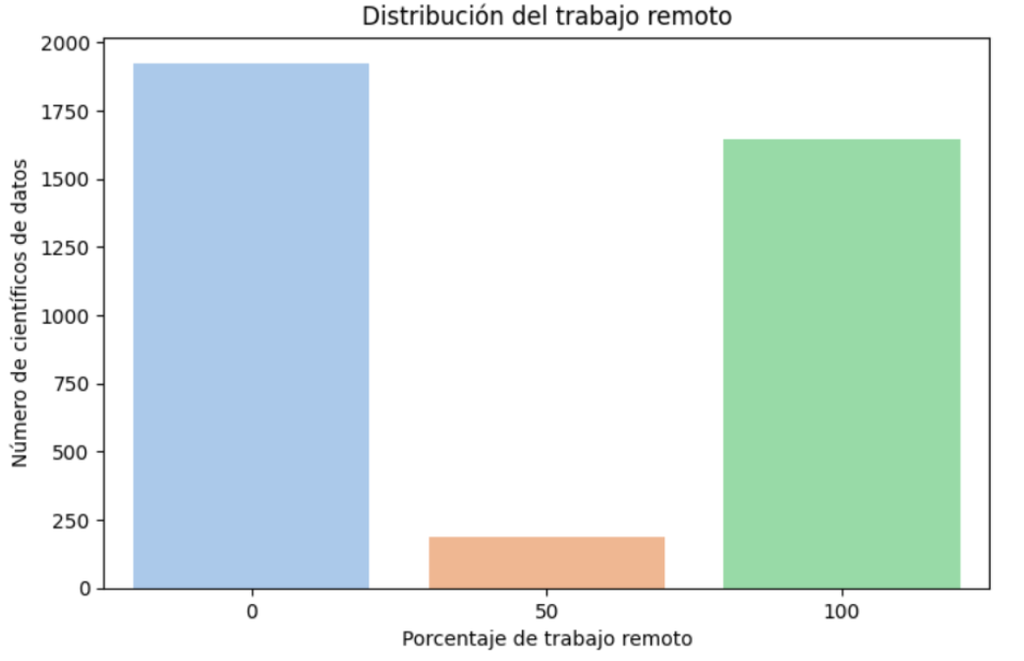

- **company_size** y **job_title** proporcionan contexto adicional para explorar correlaciones entre características de la empresa y salarios.

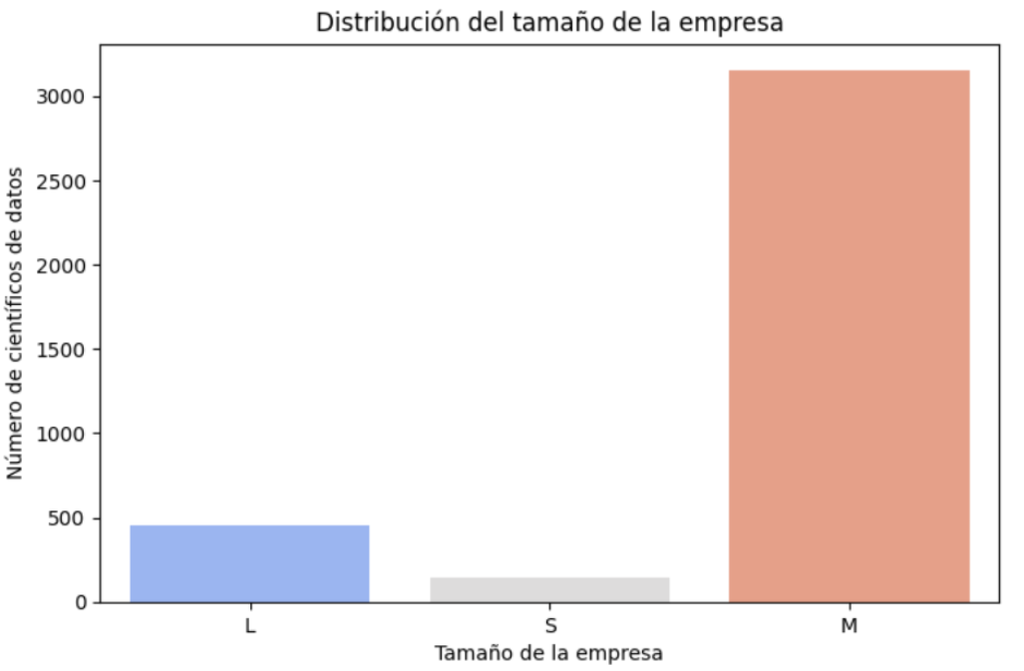

Este análisis inicial sienta las bases para un análisis más profundo en las siguientes secciones.

## 4. Análisis exploratorio de datos

Esta sección proporciona una visión inicial de cómo varían los salarios a nivel global, considerando tanto la localización como el sector.

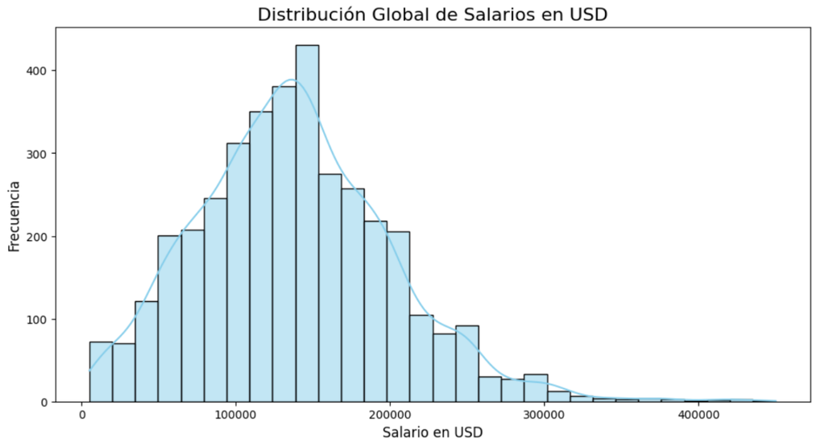

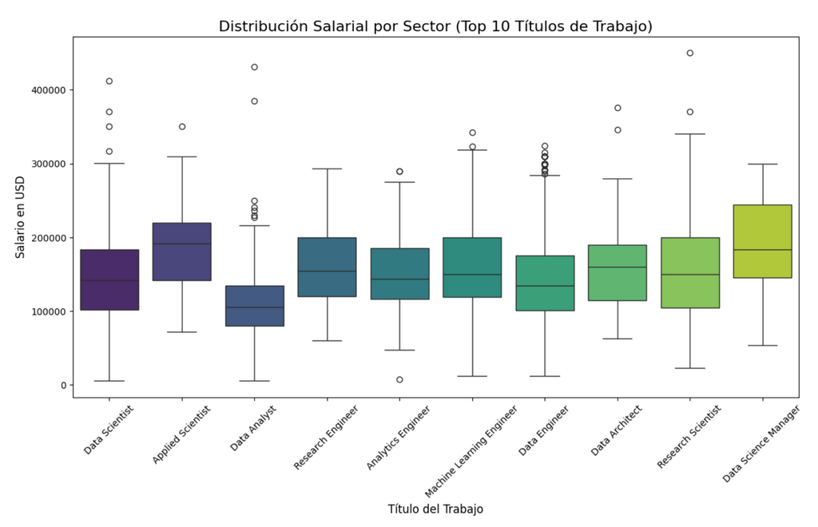

- **4.2 Impacto de la experiencia**
  - Impacto del Nivel de Experiencia:
    - Los empleados con niveles de experiencia **EX (Executive)** y **SE (Senior)** muestran las medianas salariales más altas.
    - Los niveles **MI (Mid-level)** y **EN (Entry-level)** presentan salarios considerablemente más bajos, destacando la influencia de la experiencia en el salario.

Este análisis demuestra cómo la experiencia influye significativamente en los salarios dentro del campo de la ciencia de datos.

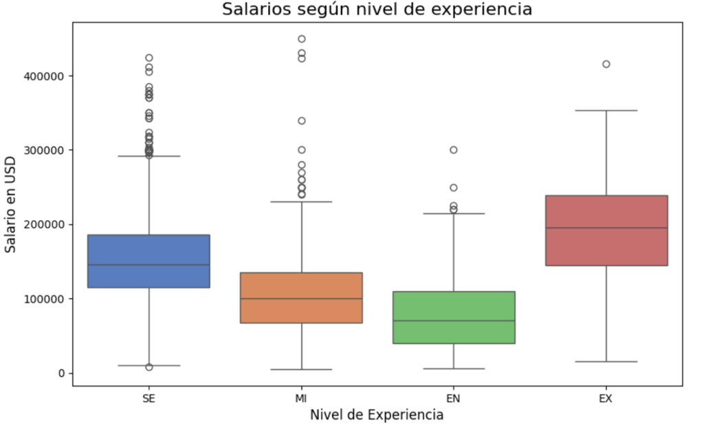

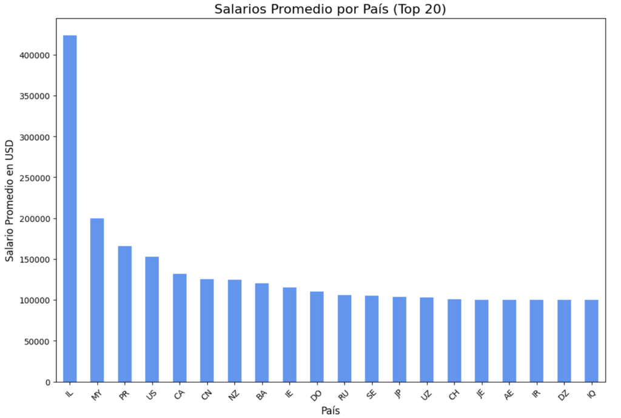

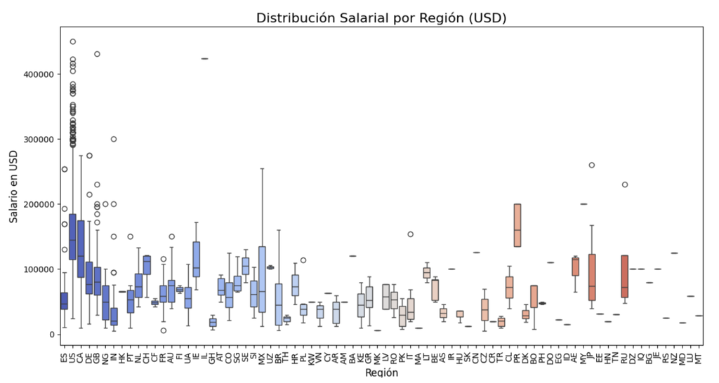

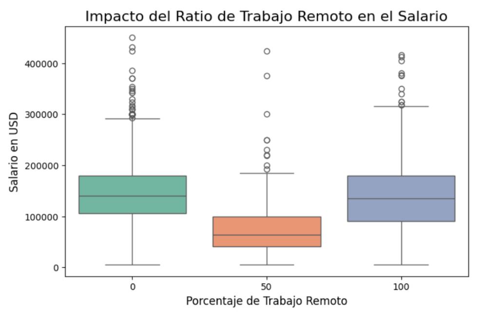

Este análisis confirma importantes disparidades salariales entre regiones y países, así como la influencia creciente del trabajo remoto en los ingresos.

## 5. Modelado predictivo

### 5.1. Selección de modelos

- 1. Regresión Lineal
  - El modelo de regresión lineal arrojó un MSE de aproximadamente 3212207066,06 y un R² de 0.1863.
  - Este modelo es útil para interpretar relaciones lineales simples, pero puede no capturar las complejidades del dataset, como interacciones no lineales entre variables.
- 2. Random Forest
  - El modelo Random Forest tuvo un MSE de aproximadamente 3170103107.52 y un R² de 0.196, superando el desempeño de la regresión lineal.
  - La naturaleza no lineal del Random Forest lo hace más adecuado para datasets complejos con relaciones no evidentes.

#### Comparativa General

- El Random Forest demostró un mejor rendimiento en términos de precisión, sugiriendo que es más adecuado para predecir salarios basándose en las características disponibles.
- Sin embargo, el modelo de Regresión Lineal sigue siendo valioso como punto de partida y para interpretaciones más sencillas.

Este análisis establece las bases para el ajuste y optimización de modelos adicionales en futuras etapas.

### 5.2. Preparación de los datos

Este proceso garantiza que los datos estén listos para ser utilizados en modelos predictivos, reduciendo la posibilidad de sesgos o problemas durante el entrenamiento de los mismos.

### 5.3. Evaluación del modelo

Tras entrenar un modelo de Random Forest Regressor, se evaluaron las métricas de desempeño tanto en el conjunto de entrenamiento como en el de prueba:

- 1. Conjunto de Entrenamiento (Train):  
     MAE: ~41635.25  
     RMSE: ~54237.86  
     R²: ~0.261

### 5.4. Interpretación de resultados

El análisis de las importancias de las características nos permite identificar las variables que tienen mayor impacto en la predicción de los salarios. A continuación, se interpretan los resultados obtenidos:

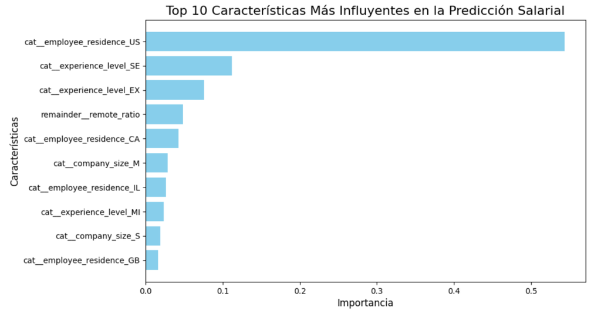

Variables más influyentes:

- 1. `employee_residence_US` (Residencia en Estados Unidos):  
     La residencia en Estados Unidos resulta ser la variable más influyente, con una importancia del **54.39%**. Esto refleja que vivir en este país es un factor determinante en los salarios de los científicos de datos, probablemente debido al alto costo de vida, la demanda del mercado y la prevalencia de empresas tecnológicas con salarios elevados.
- 2. `experience_level_SE` (Nivel de experiencia Senior): El nivel de experiencia Senior tiene una importancia del **11.20%**, lo que subraya cómo la experiencia profesional influye directamente en los salarios. Los roles senior suelen estar asociados con mayor responsabilidad y habilidades técnicas avanzadas.
- 3. `experience_level_EX` (Nivel de experiencia Ejecutivo):  
     Con una influencia del **7.55%**, el nivel Ejecutivo también contribuye significativamente, aunque menos que el nivel Senior. Esto puede deberse a la menor representación de roles ejecutivos en el dataset.
- 4. `remote_ratio` (Porcentaje de trabajo remoto): El trabajo remoto tiene una importancia del **4.84%**, lo que refleja su relevancia creciente en un mundo post-pandemia. Trabajar completamente remoto permite acceder a empleadores globales, lo que podría influir en los salarios.
- 5. `employee_residence_CA` (Residencia en Canadá): La residencia en Canadá aporta un **4.25%** de influencia, indicando que, aunque los salarios son menores en comparación con Estados Unidos, la cercanía geográfica y las oportunidades tecnológicas en el país lo convierten en un factor relevante.

#### Conclusión:

La residencia (especialmente en Estados Unidos y Canadá) y el nivel de experiencia son los factores más determinantes en la predicción salarial. Esto subraya cómo el mercado laboral global y las habilidades técnicas avanzadas están estrechamente relacionados con los ingresos en la ciencia de datos.

En futuras secciones, se podría explorar cómo estas variables interactúan entre sí y cómo otros factores, como el tamaño de la empresa, podrían influir de manera combinada en los resultados.

### 5.5. Entrenamiento de red neuronal y comparación con nuestro modelo entrenado

En este apartado, exploramos de manera experimental el desempeño de un modelo basado en red neuronal en comparación con nuestro modelo entrenado de Random Forest.

**Comparación de Métricas**

Las métricas obtenidas para ambos modelos fueron las siguientes:

- Modelo Random Forest: Conjunto de Entrenamiento: MAE = 41,635.25; RMSE = 54,237.87; R² = 0.2610 Conjunto de Prueba: MAE = 43,727.13; RMSE = 56,299.67; R² = 0.1971
- Modelo de Red Neuronal: Conjunto de Entrenamiento: MAE = 39,136.70; RMSE = 52,074.49; R² = 0.3188 Conjunto de Prueba: MAE = 39,840.11; RMSE = 51,410.44; R² = 0.3305

La comparación de estas métricas revela que el modelo de red neuronal tiene un desempeño superior al Random Forest. Específicamente:

- Error Medio Absoluto (MAE): La red neuronal presenta un MAE menor tanto en entrenamiento como en prueba (39,136.70 y 39,840.11, respectivamente) en comparación con el Random Forest (41,635.25 y 43,727.13). Esto indica que, en promedio, las predicciones de la red neuronal se desvían menos de los valores reales (Scikit-Learn Documentation).
- Raíz del Error Cuadrático Medio (RMSE): De igual forma, el RMSE de la red neuronal es menor (52,074.49 en entrenamiento y 51,410.44 en prueba) frente a los 54,237.87 y 56,299.67 del Random Forest. Esto sugiere que la red neuronal maneja mejor los errores grandes, penalizando menos las grandes desviaciones (Analytics Vidhya).
- Coeficiente de Determinación (R²): El R² del modelo de red neuronal es mayor, alcanzando 0.3188 en entrenamiento y 0.3305 en prueba, en comparación con 0.2610 y 0.1971 para el Random Forest. Esto implica que la red neuronal explica una mayor proporción de la variabilidad en el salario, lo que se traduce en una mejor capacidad de predicción (Towards Data Science).

**Implicaciones de la Comparación**

Estos resultados muestran claramente el potencial de las redes neuronales para capturar relaciones complejas y no lineales en los datos. Sin embargo, es importante considerar que:

- Requerimientos de Hardware: El entrenamiento de redes neuronales demanda recursos computacionales significativos. El uso de GPUs o TPUs es esencial para reducir los tiempos de entrenamiento y manejar grandes volúmenes de datos, lo que puede no ser viable en todos los entornos operativos.
- Complejidad en la Interpretación: A pesar de obtener métricas superiores, las redes neuronales se consideran “cajas negras”, lo que dificulta la interpretación de los factores individuales que influyen en la predicción, a diferencia de los modelos basados en árboles como el Random Forest, que ofrecen una mayor interpretabilidad a través de la importancia de las características.
- Aplicación Práctica: Aunque las métricas mejoradas de la red neuronal sugieren un mayor potencial predictivo, en este estudio se opta por emplear el modelo Random Forest en la fase de productivización, dada su menor complejidad y menores requerimientos de hardware. La red neuronal se utiliza aquí a modo de exploración y para mostrar que, en entornos con los recursos adecuados, se podría obtener una mayor precisión en las predicciones.

Conclusión

La inclusión de este apartado evidencia que, a nivel experimental, las redes neuronales pueden superar a los modelos tradicionales en términos de precisión (menor MAE y RMSE, mayor R²). No obstante, la elección del modelo para la interpretación y productivización se basa en un equilibrio entre desempeño y viabilidad operativa. En este caso, se opta por el Random Forest debido a sus menores requerimientos computacionales y su mayor interpretabilidad, a pesar de que la red neuronal mostró mejores métricas en la fase de validación.

Este análisis comparativo no solo subraya el potencial de las técnicas de Deep Learning, sino que también destaca la importancia de adaptar la elección del modelo a las capacidades y recursos disponibles, ofreciendo así una perspectiva integral sobre el proceso de modelado en ciencia de datos.

### 6. Productivización del modelo

De cara a la productivización del modelo, después de hacer un análisis de las herramientas disponibles en el mercado, me he decantado por la herramienta **Streamlit**, ya que es una herramienta fácil de usar para crear aplicaciones interactivas basadas en Python. Con ella, es posible desarrollar una interfaz donde los usuarios ingresen datos y vean las predicciones.

Con el código presente en el anexo, crearemos un fichero ejecutable con python que pondrá en marcha la aplicación web, que tendrá un aspecto como el de la imagen, y que nos permitirá ingresar los datos y hacer predicciones con el modelo.

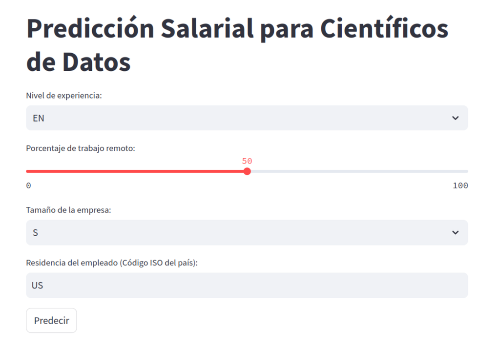

## 7. Análisis de resultados, conclusiones y recomendaciones

### 7.1. Discusión de los hallazgos principales

En este análisis sobre los factores que influyen en los salarios de los científicos de datos, se han identificado varias tendencias clave que destacan por su relevancia:

#### 1. Distribución Salarial Global:

Los salarios de los científicos de datos varían considerablemente a nivel mundial. Factores como la ubicación geográfica, el nivel de experiencia y el tipo de industria influyen en estas diferencias salariales. Por ejemplo, en países desarrollados, los salarios tienden a ser más altos en comparación con países en desarrollo.

#### 2. Impacto del Nivel de Experiencia:

Existe una correlación positiva entre el nivel de experiencia y la remuneración. Los profesionales con mayor experiencia suelen recibir salarios más elevados. Por ejemplo, un científico de datos con experiencia senior o ejecutiva percibe salarios significativamente más altos que aquellos en niveles de entrada o intermedios.

#### 3. Influencia del Tipo de Empleo:

El tipo de empleo también afecta los salarios. Los contratos a tiempo completo suelen ofrecer remuneraciones más altas en comparación con contratos temporales o de medio tiempo.

#### 4. Efecto de la Ubicación Geográfica:

La ubicación geográfica es un factor determinante en la variación salarial. Regiones con economías más fuertes y una mayor demanda de profesionales de datos ofrecen salarios más competitivos. Por ejemplo, países como Estados Unidos, Canadá y algunos países europeos presentan salarios promedio más altos para científicos de datos.

#### 6. Tendencias en el Trabajo Remoto:

Con el auge del trabajo remoto, se observa una tendencia en la que las empresas ofrecen salarios competitivos para roles que permiten el trabajo a distancia. Esto ha ampliado las oportunidades para los científicos de datos, permitiéndoles acceder a posiciones bien remuneradas sin restricciones geográficas.

**Conclusión**:

El análisis de este conjunto de datos destaca la influencia de múltiples factores en la determinación de los salarios en el campo de la ciencia de datos. Comprender estas tendencias es esencial tanto para los profesionales que buscan optimizar su trayectoria profesional como para las organizaciones que desean atraer y retener talento en un mercado competitivo.

### 7.2 Implicaciones para profesionales

El análisis de los datos revela que el nivel de experiencia es uno de los factores más determinantes en la remuneración. Los profesionales con roles senior o ejecutivos tienen una mayor capacidad de negociación salarial, lo que se traduce en compensaciones significativamente superiores. Esto tiene varias implicaciones prácticas:

- Planificación de Carrera y Especialización: Los profesionales deben invertir en formación continua y en especializarse en áreas técnicas de alta demanda (como machine learning, deep learning, y análisis de big data) para incrementar su valor en el mercado. La experiencia acumulada y la especialización son claves para avanzar en la escala salarial.
- Negociación Salarial: Conociendo las tendencias identificadas, los científicos de datos pueden utilizar estos datos como referencia para negociar mejores condiciones laborales. Saber que la ubicación geográfica y el tipo de contrato influyen de forma significativa en los salarios, permite argumentar con datos sólidos durante las entrevistas y revisiones salariales.
- Adaptación al Trabajo Remoto: La creciente importancia del trabajo remoto, evidenciada en el análisis, sugiere que los profesionales que opten por modelos laborales flexibles pueden acceder a oportunidades internacionales, lo cual puede traducirse en salarios más competitivos. Aprovechar estas modalidades puede ampliar la oferta laboral y las posibilidades de crecimiento profesional.

### 7.3 Recomendaciones para la industria

Para las organizaciones, el estudio del repositorio ofrece claves para diseñar estrategias de contratación y retención de talento en el área de la ciencia de datos:

- Estrategias de Remuneración Competitiva: Las empresas deben tener en cuenta que los salarios varían significativamente según el nivel de experiencia, el tipo de contrato y la ubicación. Ajustar las escalas salariales de acuerdo con estas variables puede ayudar a atraer a los mejores candidatos. Asimismo, ofrecer beneficios adicionales, como oportunidades de formación y certificación, puede ser un diferenciador importante.
- Políticas de Trabajo Remoto: La capacidad de ofrecer modalidades de trabajo remoto se ha convertido en un factor decisivo. Implementar políticas flexibles que permitan el trabajo a distancia puede ampliar el grupo de talento al que se tiene acceso y, al mismo tiempo, optimizar costos operativos. Esto es especialmente relevante en mercados donde la competencia por los perfiles de datos es alta.
- Desarrollo del Talento Interno: Invertir en el desarrollo profesional de los empleados actuales, mediante programas de capacitación y planes de carrera, no solo mejora la retención, sino que también puede justificar escalas salariales ajustadas a la experiencia y especialización adquirida. Esto genera un ambiente de trabajo competitivo y orientado al crecimiento.

### 7.4 Limitaciones del análisis

#### 7.4.1 Cobertura y representatividad de la muestra

- Tamaño y diversidad:  
  El dataset contiene 3755 registros y 11 columnas. Aunque este número de observaciones es adecuado para ciertos análisis exploratorios, puede no ser representativo de toda la población global de científicos de datos. La muestra podría estar sesgada hacia determinadas regiones o sectores industriales, lo que limita la generalización de los hallazgos a contextos más amplios.
- Variables limitadas: A pesar de incluir información clave como el año de trabajo, nivel de experiencia, tipo de empleo, salario, moneda, residencia del empleado, ratio de trabajo remoto, ubicación de la empresa y tamaño de la empresa, el dataset carece de variables que podrían enriquecer el análisis, tales como el género, la educación, certificaciones específicas o detalles sobre habilidades técnicas avanzadas. La ausencia de estos datos impide profundizar en análisis más detallados y segmentados.
- Calidad y precisión de los datos:  
  Es posible que existan errores en la entrada de datos, como discrepancias en la conversión de moneda o registros atípicos (outliers) que, si bien se identificaron, pueden afectar la robustez de las conclusiones. La calidad de la información es fundamental para obtener resultados precisos y confiables, y cualquier error en la recolección o procesamiento de datos impactará directamente en las inferencias realizadas

#### 7.4.2 Limitaciones de los métodos utilizados

##### Selección y Preprocesamiento de Variables

- Codificación y transformación: La transformación de variables categóricas mediante técnicas como OneHotEncoder o get_dummies, si bien es estándar, puede introducir complejidad adicional y generar matrices de características de alta dimensión. Esta alta dimensionalidad puede afectar el rendimiento de ciertos modelos y, en casos extremos, llevar a problemas de sobreajuste si no se cuenta con suficientes datos para cada categoría.
- Falta de variables críticas: La ausencia de indicadores de habilidades técnicas específicas (como el dominio de Python, SQL, etc.) y otros atributos relevantes, como la educación o certificaciones, limita la capacidad del modelo para capturar la complejidad real de los factores que influyen en el salario. Esto implica que el modelo puede no ser lo suficientemente robusto para predecir variaciones salariales basadas en todos los factores determinantes.

##### Modelado y Evaluación

- Impacto de los outliers:  
  La presencia de valores atípicos en la variable "salary_in_usd" puede distorsionar las métricas de rendimiento y la interpretación de los resultados. Aunque se identifican y se pueden tratar con técnicas estadísticas, el manejo inadecuado de estos valores puede sesgar las conclusiones, sobre todo en análisis de regresión y evaluación de modelos

#### 7.4.3 Conclusiones y recomendaciones

##### Reflexiones sobre las limitaciones

- Cautela en la interpretación:  
  Es fundamental interpretar los resultados con cautela, entendiendo que las conclusiones derivadas son válidas únicamente para la muestra analizada y que podrían variar si se incorpora un dataset más completo o diverso. La generalización de los hallazgos a nivel global debe realizarse considerando estas limitaciones intrínsecas.
- Necesidad de datos complementarios:  
  Para obtener un análisis más profundo y robusto, se recomienda complementar este dataset con información adicional sobre variables críticas como género, nivel educativo, certificaciones y habilidades específicas. Esto permitiría construir modelos predictivos más precisos y ofrecer recomendaciones más personalizadas.

### 7.5 Trabajo futuro

- Exploración de métodos avanzados:  
  Se sugiere la implementación y comparación de métodos de modelado más avanzados, como modelos de boosting y redes neuronales, para evaluar si logran captar mejor las complejidades y no linealidades de los datos.
- Análisis de interacción de variables:  
  Investigar cómo interactúan las diferentes variables (por ejemplo, experiencia y ubicación, o tipo de empleo y tamaño de la empresa) podría proporcionar una visión más detallada de los factores que influyen en el salario y ayudar a desarrollar estrategias de negociación salarial y políticas de recursos humanos más precisas.
- Validación con datos externos:  
  La integración y comparación de este análisis con otros datasets disponibles a nivel internacional, o con estudios de consultoras especializadas, podría enriquecer la validez externa de las conclusiones y ofrecer un marco comparativo más sólido.

## 9. Referencias

1. **Big Data y Ciencia de Datos**
   - Marr, B. (2016). Big Data in Practice: How 45 Successful Companies Used Big Data Analytics to Deliver Extraordinary Results. Wiley.
   - Davenport, T. H., & Patil, D. J. (2012). Data Scientist: The Sexiest Job of the 21st Century. Harvard Business Review. [Disponible aquí](https://hbr.org/2012/10/data-scientist-the-sexiest-job-of-the-21st-century)
2. **Tendencias de empleo y mercado laboral**
   - LinkedIn. (2023). Jobs on the Rise. Informe anual de empleos más demandados.
   - Glassdoor. (2023). 50 Best Jobs in America.
3. **Automatización y herramientas en ciencia de datos**
   - Microsoft. (2020). Introduction to Automated Machine Learning. [Disponible aquí](https://docs.microsoft.com/en-us/azure/machine-learning/concept-automated-ml)
   - Gartner. (2022). Emerging Technologies and Trends Impact Radar: Artificial Intelligence.
4. **Proyección y especialización**
   - McKinsey & Company. (2021). The Future of Work after COVID-19.
   - World Economic Forum. (2023). The Future of Jobs Report.

## Anexo: código

## Importe del dataset

```python
import matplotlib.pyplot as plt
import seaborn as sns
import kagglehub

import pandas as pd

path_data = kagglehub.dataset_download("henryshan/2023-data-scientists-salary")
print("Path to dataset files:", path_data)
```

```
Extracting files...
Path to dataset files: /root/.cache/kagglehub/datasets/henryshan/2023-data-scientists-salary/versions/1
```

```python
data = pd.read_csv(path_data + "/ds_salaries.csv",sep=",")
```

## 3.3. Exploración inicial

```
Dimensiones del dataset: (3755, 11)
Estadísticas descriptivas de la variable 'salary_in_usd':
count      3755.000000
mean     137570.389880
std       63055.625278
min        5132.000000
25%       95000.000000
50%      135000.000000
75%      175000.000000
max      450000.000000
Name: salary_in_usd, dtype: float64
```

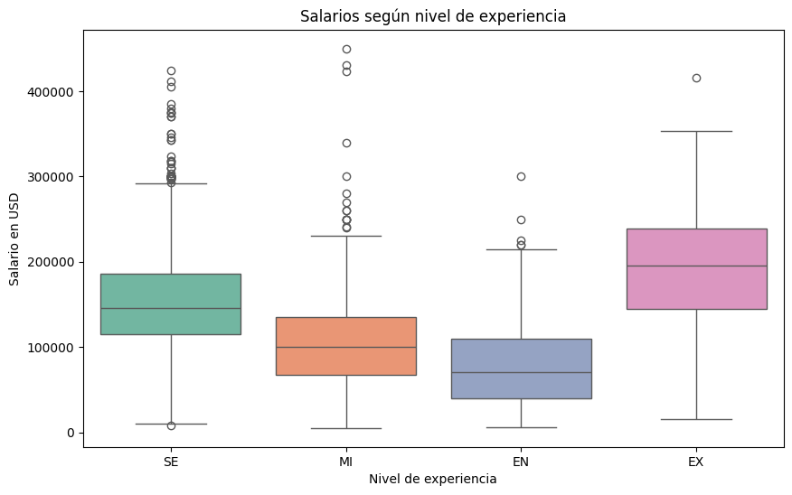

```
Valores atípicos identificados: 63 registros
Datos faltantes por columna:
work_year             0
experience_level      0
employment_type       0
job_title             0
salary                0
salary_currency       0
salary_in_usd         0
employee_residence    0
remote_ratio          0
company_location      0
company_size          0
dtype: int64
```

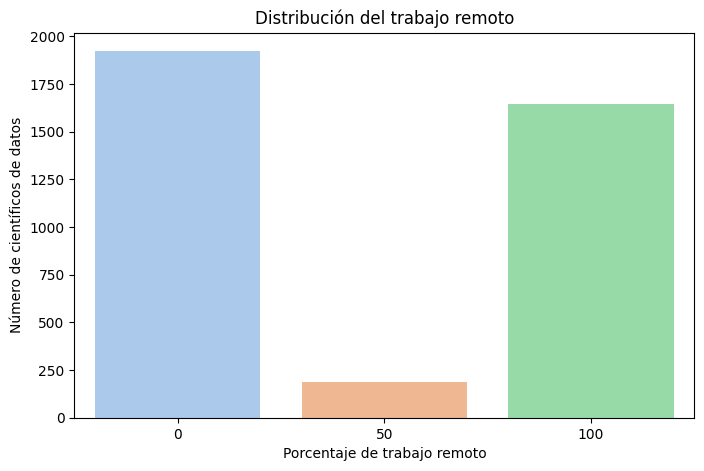

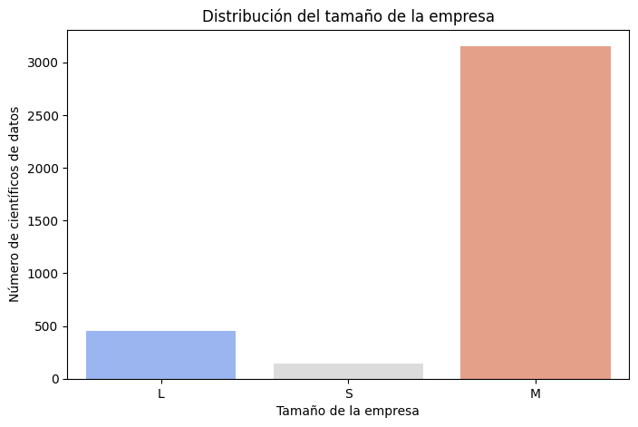

```python
# 1. Dimensiones del dataset
print("Dimensiones del dataset:", data.shape)

# 2. Tendencias preliminares
# Estadísticas descriptivas de los salarios en USD
print("Estadísticas descriptivas de la variable 'salary_in_usd':")
print(data['salary_in_usd'].describe())

# Gráfico de dispersión para explorar la relación entre experiencia y salario
plt.figure(figsize=(10, 6))
sns.boxplot(x="experience_level", y="salary_in_usd", data=data, palette="Set2", legend=False, hue="experience_level")
plt.title("Salarios según nivel de experiencia")
plt.xlabel("Nivel de experiencia")
plt.ylabel("Salario en USD")
plt.show()

# 3. Valores atípicos
# Identificar valores atípicos utilizando el rango intercuartílico (IQR)
Q1 = data['salary_in_usd'].quantile(0.25)
Q3 = data['salary_in_usd'].quantile(0.75)
IQR = Q3 - Q1
outliers = data[(data['salary_in_usd'] < (Q1 - 1.5 * IQR)) | (data['salary_in_usd'] > (Q3 + 1.5 * IQR))]
print(f"Valores atípicos identificados: {outliers.shape[0]} registros")

# 4. Datos faltantes
missing_data = data.isnull().sum()
print("Datos faltantes por columna:")
print(missing_data)

# 5. Observaciones adicionales
# Distribución de trabajo remoto
plt.figure(figsize=(8, 5))
sns.countplot(x="remote_ratio", data=data, palette="pastel", legend = False, hue="remote_ratio" )
plt.title("Distribución del trabajo remoto")
plt.xlabel("Porcentaje de trabajo remoto")
plt.ylabel("Número de científicos de datos")
plt.show()

# Distribución del tamaño de la empresa
plt.figure(figsize=(8, 5))
sns.countplot(x="company_size", data=data, palette="coolwarm", legend=False, hue="company_size")
plt.title("Distribución del tamaño de la empresa")
plt.xlabel("Tamaño de la empresa")
plt.ylabel("Número de científicos de datos")
plt.show()
```

## 4.1 Distribución salarial global

```python
import matplotlib.pyplot as plt
import seaborn as sns
```

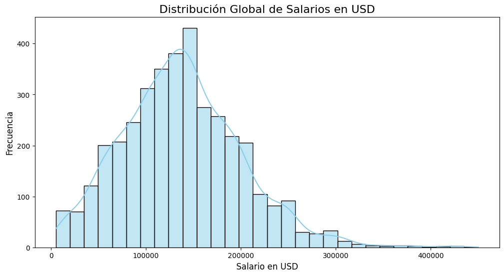

```python
# Gráfico de distribución de salarios en USD
plt.figure(figsize=(12, 6))
sns.histplot(data['salary_in_usd'], bins=30, kde=True, color="skyblue")
plt.title("Distribución Global de Salarios en USD", fontsize=16)
plt.xlabel("Salario en USD", fontsize=12)
plt.ylabel("Frecuencia", fontsize=12)
plt.show()
```

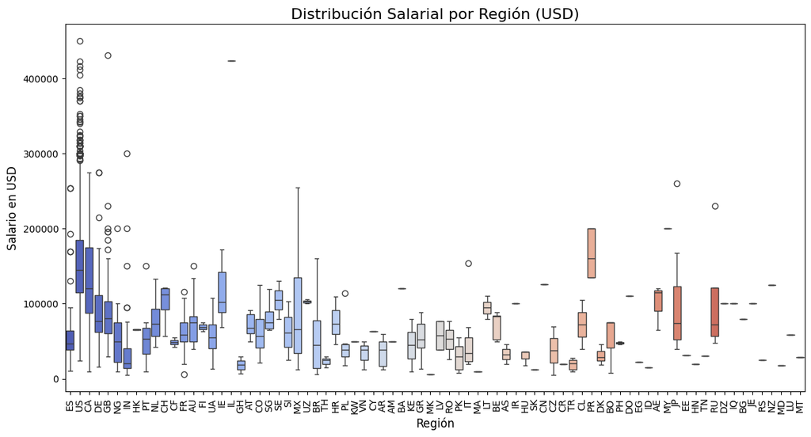

```python
# Distribución salarial por región (residencia del empleado)
plt.figure(figsize=(14, 7))
sns.boxplot(x="employee_residence", y="salary_in_usd", data=data, palette="coolwarm", legend=False, hue="employee_residence")
plt.xticks(rotation=90)
plt.title("Distribución Salarial por Región (USD)", fontsize=16)
plt.xlabel("Región", fontsize=12)
plt.ylabel("Salario en USD", fontsize=12)
plt.show()
```

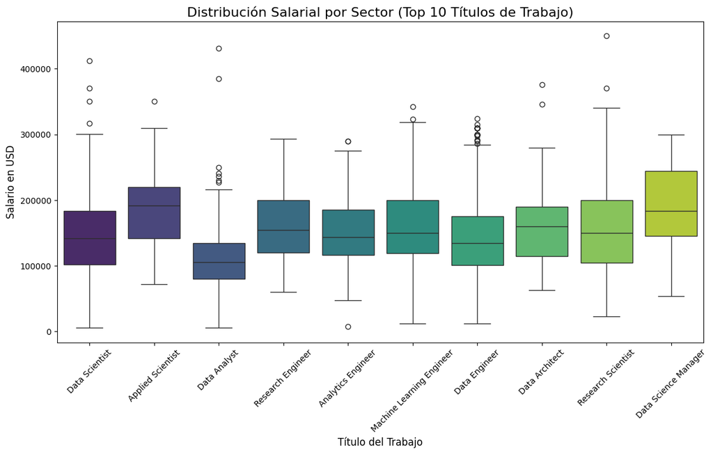

```python
# Distribución salarial por sector (título del trabajo)
plt.figure(figsize=(14, 7))
top_titles = data['job_title'].value_counts().head(10).index
data_top_titles = data[data['job_title'].isin(top_titles)]
sns.boxplot(x="job_title", y="salary_in_usd", data=data_top_titles, palette="viridis", legend=False, hue="job_title")
plt.xticks(rotation=45)
plt.title("Distribución Salarial por Sector (Top 10 Títulos de Trabajo)", fontsize=16)
plt.xlabel("Título del Trabajo", fontsize=12)
plt.ylabel("Salario en USD", fontsize=12)
plt.show()
```

## 4.3. Comparativa regional

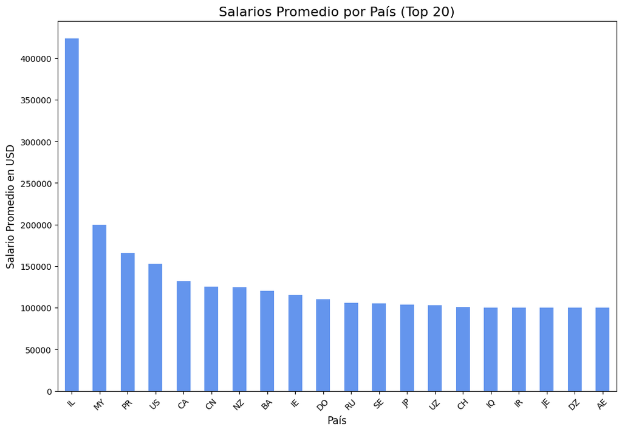

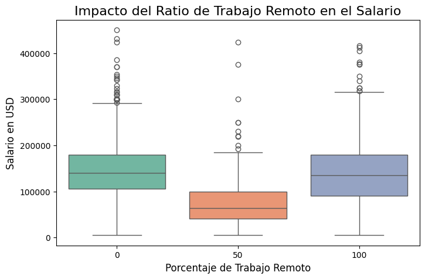

```python
# Comparativa de salarios promedio por país
avg_salary_by_country = data.groupby("employee_residence")['salary_in_usd'].mean().sort_values(ascending=False)
plt.figure(figsize=(12, 8))
avg_salary_by_country.head(20).plot(kind='bar', color="cornflowerblue")
plt.title("Salarios Promedio por País (Top 20)", fontsize=16)
plt.xlabel("País", fontsize=12)
plt.ylabel("Salario Promedio en USD", fontsize=12)
plt.xticks(rotation=45)
plt.show()

# Comparativa de salarios promedio por región remota
if 'remote_ratio' in data.columns:
    plt.figure(figsize=(8, 5))
sns.boxplot(x="remote_ratio", y="salary_in_usd", data=data, palette="Set2", hue = "remote_ratio", legend=False)
plt.title("Impacto del Ratio de Trabajo Remoto en el Salario", fontsize=16)
plt.xlabel("Porcentaje de Trabajo Remoto", fontsize=12)
plt.ylabel("Salario en USD", fontsize=12)
plt.show()
```

## 5.1 Selección de modelos

```python
from sklearn.model_selection import train_test_split
from sklearn.linear_model import LinearRegression
from sklearn.ensemble import RandomForestRegressor
from sklearn.metrics import mean_squared_error, r2_score

# Preparación de datos
X = data[["experience_level", "remote_ratio", "company_size"]]  # Variables predictoras

# Codificación de variables categóricas
X = pd.get_dummies(X, columns=["experience_level", "company_size"], drop_first=True)
y = data["salary_in_usd"]

# División en conjunto de entrenamiento y prueba
X_train, X_test, y_train, y_test = train_test_split(X, y, test_size=0.2, random_state=42)

# Entrenamiento de modelos
# Modelo 1: Regresión Lineal
lr_model = LinearRegression()
lr_model.fit(X_train, y_train)
lr_predictions = lr_model.predict(X_test)

# Modelo 2: Random Forest
rf_model = RandomForestRegressor(random_state=42, n_estimators=100)
rf_model.fit(X_train, y_train)
rf_predictions = rf_model.predict(X_test)

# Evaluación de modelos
lr_mse = mean_squared_error(y_test, lr_predictions)
lr_r2 = r2_score(y_test, lr_predictions)

rf_mse = mean_squared_error(y_test, rf_predictions)
rf_r2 = r2_score(y_test, rf_predictions)

print("Evaluación de Modelos:")
print("Regresión Lineal: MSE =", lr_mse, ", R² =", lr_r2)
print("Random Forest: MSE =", rf_mse, ", R² =", rf_r2)
```

```
Evaluación de Modelos:
Regresión Lineal: MSE = 3212207066.067692 , R² = 0.18632774287258358
Random Forest: MSE = 3170103107.5239396 , R² = 0.19699294043851534
```

## 5.2. Preparación de los datos

```python
# Importación de librerías necesarias
import pandas as pd
from sklearn.model_selection import train_test_split
from sklearn.preprocessing import StandardScaler, OneHotEncoder
from sklearn.compose import ColumnTransformer
from sklearn.pipeline import Pipeline

# Selección de variables relevantes
columns_to_use = ["experience_level", "remote_ratio", "company_size", "salary_in_usd"]
data_modeling = data[columns_to_use]

# Separación de predictores y variable objetivo
X = data_modeling.drop("salary_in_usd", axis=1)
y = data_modeling["salary_in_usd"]

# Identificación de variables categóricas y numéricas
categorical_features = ["experience_level", "company_size"]
numerical_features = ["remote_ratio"]

# Transformaciones de datos
# 1. Escalado de variables numéricas
# 2. Codificación OneHot para variables categóricas
preprocessor = ColumnTransformer(
    transformers=[
        ("num", StandardScaler(), numerical_features),
        ("cat", OneHotEncoder(drop="first"), categorical_features)
    ]
)

# División de los datos en conjuntos de entrenamiento y prueba
X_train, X_test, y_train, y_test = train_test_split(X, y, test_size=0.2, random_state=42)

# Pipeline para la preparación de datos
model = Pipeline(steps=[("preprocessor", preprocessor),
                          ("regressor", RandomForestRegressor(random_state=42))])

# Transformación de los datos
# Entrenar el modelo
model.fit(X_train, y_train)

# Hacer predicciones
y_pred = model.predict(X_test)

# Confirmación de dimensiones transformadas (opcional, pero en otro paso)
X_train_transformed = preprocessor.fit_transform(X_train)
X_test_transformed = preprocessor.transform(X_test)

# Confirmación de dimensiones finales
print("Dimensiones de X_train:", X_train_transformed.shape)
print("Dimensiones de X_test:", X_test_transformed.shape)
```

```
Dimensiones de X_train: (3004, 6)
Dimensiones de X_test: (751, 6)
```

## 5.3 Evaluación del Modelo

```python
from sklearn.metrics import mean_absolute_error, mean_squared_error, r2_score
import numpy as np

# Entrenamiento del modelo
model.fit(X_train, y_train)

# Predicciones
y_train_pred = model.predict(X_train)
y_test_pred = model.predict(X_test)

# Cálculo de métricas
metrics = {
    "Train": {
        "MAE": mean_absolute_error(y_train, y_train_pred),
        "RMSE": np.sqrt(mean_squared_error(y_train, y_train_pred)),
        "R²": r2_score(y_train, y_train_pred),
    },
    "Test": {
        "MAE": mean_absolute_error(y_test, y_test_pred),
        "RMSE": np.sqrt(mean_squared_error(y_test, y_test_pred)),
        "R²": r2_score(y_test, y_test_pred),
    }
}

# Mostrar las métricas
for dataset, values in metrics.items():
    print(f"--- {dataset} Metrics ---")
    for metric, value in values.items():
        print(f"{metric}: {value:.4f}")
```

```
--- Train Metrics ---
MAE: 41635.2515
RMSE: 54237.8656
R²: 0.2610
--- Test Metrics ---
MAE: 43727.1250
RMSE: 56299.6685
R²: 0.1971
```

## 5.4. Interpretación de resultados

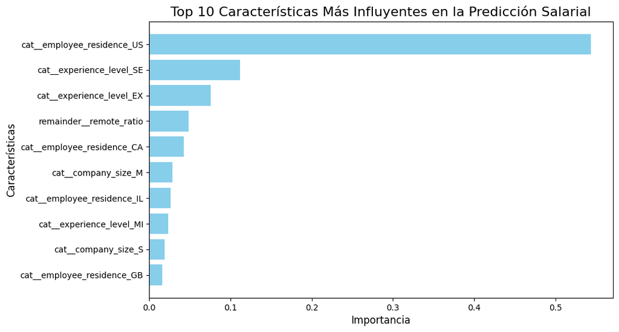

```
Top 5 variables más influyentes:
                       Feature  Importance
75  cat__employee_residence_US    0.543874
2     cat__experience_level_SE    0.112005
0     cat__experience_level_EX    0.075454
78     remainder__remote_ratio    0.048437
14  cat__employee_residence_CA    0.042536
```

```python
import pandas as pd
import matplotlib.pyplot as plt
from sklearn.ensemble import RandomForestRegressor
from sklearn.compose import ColumnTransformer
from sklearn.preprocessing import OneHotEncoder
from sklearn.pipeline import Pipeline
from sklearn.model_selection import train_test_split

# Selección de características y objetivo
X = data[["experience_level", "remote_ratio", "company_size", "employee_residence"]]
y = data["salary_in_usd"]

# Codificación de variables categóricas con manejo de categorías desconocidas
categorical_features = ["experience_level", "company_size", "employee_residence"]
preprocessor = ColumnTransformer(
    transformers=[
        ("cat", OneHotEncoder(drop="first", sparse_output=False, handle_unknown="ignore"), categorical_features)
    ],
    remainder="passthrough"
)

# División de datos en entrenamiento y prueba
X_train, X_test, y_train, y_test = train_test_split(X, y, test_size=0.2, random_state=42)

# Ajuste del preprocesador en X_train para obtener las columnas procesadas
X_train_transformed = preprocessor.fit_transform(X_train)

# Obtener nombres de las columnas transformadas
preprocessed_feature_names = preprocessor.get_feature_names_out()

# Crear DataFrame de las características transformadas
X_train_transformed_df = pd.DataFrame(X_train_transformed, columns=preprocessed_feature_names)

# Crear y entrenar el modelo
model = RandomForestRegressor(random_state=42)
model.fit(X_train_transformed_df, y_train)

# Transformar X_test con el preprocesador y convertirlo a DataFrame
X_test_transformed = preprocessor.transform(X_test)
X_test_transformed_df = pd.DataFrame(X_test_transformed, columns=preprocessed_feature_names)

# Importancia de características
feature_importances = model.feature_importances_
importance_df = pd.DataFrame({
    "Feature": preprocessed_feature_names,
    "Importance": feature_importances
}).sort_values(by="Importance", ascending=False)

top_10_features = importance_df.nlargest(10, "Importance")

# Crear el gráfico de barras horizontal
plt.figure(figsize=(10, 6))
plt.barh(top_10_features["Feature"], top_10_features["Importance"], color="skyblue")
plt.gca().invert_yaxis()  # Invertir el eje y para que las características más importantes estén arriba
plt.title("Top 10 Características Más Influyentes en la Predicción Salarial", fontsize=16)
plt.xlabel("Importancia", fontsize=12)
plt.ylabel("Características", fontsize=12)
plt.show()

# Mostrar las variables más influyentes
print("Top 5 variables más influyentes:")
print(importance_df.head(5))
```

# 5.5. Entrenamiento de red neuronal y comparación con nuestro modelo entrenado

```python
!pip install tensorflow
```

```python
import pandas as pd
import numpy as np
from sklearn.model_selection import train_test_split
from sklearn.preprocessing import StandardScaler, OneHotEncoder
from sklearn.compose import ColumnTransformer
from sklearn.metrics import mean_absolute_error, mean_squared_error, r2_score
import tensorflow as tf
from tensorflow.keras.models import Sequential
from tensorflow.keras.layers import Dense, Dropout
from tensorflow.keras.callbacks import EarlyStopping

# Selección de características y variable objetivo
X = data[["experience_level", "remote_ratio", "company_size", "employee_residence"]]
y = data["salary_in_usd"]

# Definir las columnas categóricas y numéricas
categorical_features = ["experience_level", "company_size", "employee_residence"]
numerical_features = ["remote_ratio"]

# Crear un preprocesador para escalar las variables numéricas y codificar las categóricas
preprocessor = ColumnTransformer(
    transformers=[
        ("num", StandardScaler(), numerical_features),
        ("cat", OneHotEncoder(drop='first', handle_unknown='ignore'), categorical_features)
    ]
)

# Dividir el dataset en conjuntos de entrenamiento y prueba
X_train, X_test, y_train, y_test = train_test_split(X, y, test_size=0.2, random_state=42)

# Ajustar el preprocesador en los datos de entrenamiento y transformar ambos conjuntos
X_train_transformed = preprocessor.fit_transform(X_train)
X_test_transformed = preprocessor.transform(X_test)

# Determinar la dimensión de entrada para el modelo
input_dim = X_train_transformed.shape[1]

# Construir el modelo de red neuronal
model_nn = Sequential([
    Dense(64, activation='relu', input_dim=input_dim),
    Dropout(0.2),
    Dense(32, activation='relu'),
    Dropout(0.2),
    Dense(1)  # Capa de salida para regresión
])

# Compilar el modelo
model_nn.compile(optimizer='adam', loss='mse', metrics=['mae'])

# Definir Early Stopping para prevenir sobreajuste
early_stop = EarlyStopping(monitor='val_loss', patience=10, restore_best_weights=True)

# Entrenar el modelo
history = model_nn.fit(
    X_train_transformed, y_train,
    validation_split=0.2,
    epochs=100,
    batch_size=32,
    callbacks=[early_stop],
    verbose=1
)

# Realizar predicciones en los conjuntos de entrenamiento y prueba
y_train_pred_nn = model_nn.predict(X_train_transformed).flatten()
y_test_pred_nn = model_nn.predict(X_test_transformed).flatten()

# Calcular métricas para el modelo de red neuronal
mae_train_nn = mean_absolute_error(y_train, y_train_pred_nn)
rmse_train_nn = np.sqrt(mean_squared_error(y_train, y_train_pred_nn))
r2_train_nn = r2_score(y_train, y_train_pred_nn)

mae_test_nn = mean_absolute_error(y_test, y_test_pred_nn)
rmse_test_nn = np.sqrt(mean_squared_error(y_test, y_test_pred_nn))
r2_test_nn = r2_score(y_test, y_test_pred_nn)

print("Desempeño del Modelo de Red Neuronal:")
print("Conjunto de Entrenamiento - MAE: {:.2f}, RMSE: {:.2f}, R²: {:.4f}".format(mae_train_nn, rmse_train_nn, r2_train_nn))
print("Conjunto de Prueba       - MAE: {:.2f}, RMSE: {:.2f}, R²: {:.4f}".format(mae_test_nn, rmse_test_nn, r2_test_nn))
```

[output not shown]

[output cut: 50 more lines]

```
76/76 ━━━━━━━━━━━━━━━━━━━━ 1s 5ms/step - loss: 3227070464.0000 - mae: 41510.4102 - val_loss: 2345956352.0000 - val_mae: 38529.4961
76/76 ━━━━━━━━━━━━━━━━━━━━ 1s 5ms/step - loss: 3140430080.0000 - mae: 42004.2891 - val_loss: 2342956544.0000 - val_mae: 38500.0586
76/76 ━━━━━━━━━━━━━━━━━━━━ 0s 4ms/step - loss: 3211265280.0000 - mae: 42861.5664 - val_loss: 2341244672.0000 - val_mae: 38443.7070
76/76 ━━━━━━━━━━━━━━━━━━━━ 2s 25ms/step - loss: 3080951808.0000 - mae: 42351.0234 - val_loss: 2338870016.0000 - val_mae: 38439.6758
76/76 ━━━━━━━━━━━━━━━━━━━━ 1s 8ms/step - loss: 3260915712.0000 - mae: 42751.0820 - val_loss: 2335585536.0000 - val_mae: 38414.9297
76/76 ━━━━━━━━━━━━━━━━━━━━ 1s 5ms/step - loss: 3143176960.0000 - mae: 41948.2773 - val_loss: 2334304768.0000 - val_mae: 38336.0117
76/76 ━━━━━━━━━━━━━━━━━━━━ 0s 6ms/step - loss: 3221486848.0000 - mae: 42756.1094 - val_loss: 2331682560.0000 - val_mae: 38322.1484
76/76 ━━━━━━━━━━━━━━━━━━━━ 1s 8ms/step - loss: 3027991040.0000 - mae: 41034.1367 - val_loss: 2329389312.0000 - val_mae: 38305.3945
76/76 ━━━━━━━━━━━━━━━━━━━━ 1s 8ms/step - loss: 3079359232.0000 - mae: 41108.7891 - val_loss: 2326505472.0000 - val_mae: 38283.8281
76/76 ━━━━━━━━━━━━━━━━━━━━ 1s 5ms/step - loss: 2918608640.0000 - mae: 40456.5078 - val_loss: 2324040704.0000 - val_mae: 38264.9141
94/94 ━━━━━━━━━━━━━━━━━━━━ 2s 18ms/step
24/24 ━━━━━━━━━━━━━━━━━━━━ 0s 13ms/step
Desempeño del Modelo de Red Neuronal:
Conjunto de Entrenamiento - MAE: 39136.70, RMSE: 52074.49, R²: 0.3188
Conjunto de Prueba       - MAE: 39840.11, RMSE: 51410.44, R²: 0.3305
```

## 6. Productivización del modelo

```python
import joblib

# Guardar el modelo en un archivo .pkl
joblib.dump(model, "model.pkl")
joblib.dump(preprocessor, "preprocessor.pkl")
print("Modelo guardado como 'model.pkl'")
```

```
Modelo guardado como 'model.pkl'
```

```python
import streamlit as st
import joblib
import numpy as np

# Cargar el modelo y el preprocesador
model = joblib.load("model.pkl")
preprocessor = joblib.load("preprocessor.pkl")

st.title("Predicción Salarial para Científicos de Datos")

# Crear entradas de usuario para las características necesarias
experience_level = st.selectbox("Nivel de experiencia:", ["EN", "MI", "SE", "EX"])
remote_ratio = st.slider("Porcentaje de trabajo remoto:", 0, 100, 50)
company_size = st.selectbox("Tamaño de la empresa:", ["S", "M", "L"])
employee_residence = st.text_input("Residencia del empleado (Código ISO del país):", "US")

# Crear un botón para predecir
if st.button("Predecir"):
    try:
        # Crear un dataframe para las entradas
        user_input = {
            "experience_level": [experience_level],
            "remote_ratio": [remote_ratio],
            "company_size": [company_size],
            "employee_residence": [employee_residence],
        }

        # Transformar las entradas con el preprocesador
        X_input = preprocessor.transform(user_input)

        # Hacer la predicción
        prediction = model.predict(X_input)

        st.success(f"El salario estimado es: ${prediction[0]:,.2f} USD")

    except Exception as e:
        st.error(f"Error al realizar la predicción: {e}")
```

[output not shown]

```python
# Script para escribir el archivo app.py
file_name = "productivizacion.py"

code = """import streamlit as st
import joblib
import numpy as np

# Cargar el modelo y el preprocesador
model = joblib.load("model.pkl")
preprocessor = joblib.load("preprocessor.pkl")

st.title("Predicción Salarial para Científicos de Datos")

# Crear entradas de usuario para las características necesarias
experience_level = st.selectbox("Nivel de experiencia:", ["EN", "MI", "SE", "EX"])
remote_ratio = st.slider("Porcentaje de trabajo remoto:", 0, 100, 50)
company_size = st.selectbox("Tamaño de la empresa:", ["S", "M", "L"])
employee_residence = st.text_input("Residencia del empleado (Código ISO del país):", "US")

# Crear un botón para predecir
if st.button("Predecir"):
    try:
        # Crear un dataframe para las entradas
        user_input = {
            "experience_level": [experience_level],
            "remote_ratio": [remote_ratio],
            "company_size": [company_size],
            "employee_residence": [employee_residence],
        }

        # Transformar las entradas con el preprocesador
        X_input = preprocessor.transform(user_input)

        # Hacer la predicción
        prediction = model.predict(X_input)

        st.success(f"El salario estimado es: ${prediction[0]:,.2f} USD")
    except Exception as e:
        st.error(f"Error al realizar la predicción: {e}")
"""

# Escribir el código en el archivo app.py
with open(file_name, "w") as file:
    file.write(code)

print(f"El archivo {file_name} ha sido creado exitosamente.")
```

```
El archivo productivizacion.py ha sido creado exitosamente.
```

```python
# Para ejecutar la aplicacion web que productiviza el modelo:
!streamlit run productivizacion.py
```

```
  You can now view your Streamlit app in your browser.

  Local URL: http://localhost:8501
  Network URL: http://192.168.1.58:8501
```